# Unsupervised sensory image classification

**This example takes a google image (preloaded in the Rsenal package), extracts some structural properties of the land surface and applies k-means algorithm in order to identify three clusters or types of vegetation.**

## Load libraries

```r
#The first time it is required to install devtools, leaflet, satellite, Rsenal and RColorBrewer:
#install.packages("devtools");
#library(devtools)
#devtools::install_github("rstudio/leaflet")
#install package satellite from a local file zip
#(downloaded from https://cran.r-project.org/web/packages/satellite/index.html)
#install_github("environmentalinformatics-marburg/Rsenal")
#install.packages("RColorBrewer")
library(devtools)
library(satellite)
library(leaflet)
library(Rsenal)
library(RColorBrewer)
library(lattice)
lib <- c("Rsenal", "cluster", "rasterVis", "RColorBrewer")
jnk <- sapply(lib, function(x) library(x, character.only = TRUE))
```

Definition of a 3-by-3 and 5-by-5 focal matrix

```r
  mat_w3by3 <- matrix(c(1, 1, 1,
                      1, 1, 1,
                      1, 1, 1), nc = 3)

  mat_w5by5 <- matrix(c(1, 1, 1, 1, 1,
                      1, 1, 1, 1, 1,
                      1, 1, 0, 1, 1,
                      1, 1, 1, 1, 1,
                      1, 1, 1, 1, 1), nc = 5)
```

## Load a image

Rsenal includes a built-in dataset (data(gmap_hel)) that shall serve as a basis for an unsupervised classification approach. The image is originated from Google Maps

[figure not shown]

```r
data(gmap_hel, package = "Rsenal")
#gmap_hel is A rasterBrick (a multi-layer raster object).
#gmap_hel
#gmap_hel[1,1] #rgb of the first cell
plotRGB(gmap_hel)
```

## Extraction of structural properties:

Extraction of structural properties from the red, green and blue input bands including:

- focal means and standard deviations,
- a visible vegetation index and
- a shadow mask.

```r
gmap_hel_fcmu <- lapply(1:nlayers(gmap_hel), function(i) {
  focal(gmap_hel[[i]], w = mat_w5by5, fun = mean, na.rm = TRUE, pad = TRUE)
})
gmap_hel_fcmu <- stack(gmap_hel_fcmu)


gmap_hel_fcsd <- lapply(1:nlayers(gmap_hel), function(i) {
  focal(gmap_hel[[i]], w = mat_w5by5, fun = sd, na.rm = TRUE, pad = TRUE)
})
gmap_hel_fcsd <- stack(gmap_hel_fcsd)


gmap_hel_vvi <- vvi(gmap_hel)
#gmap_hel_vvi

## shadow detection
gmap_hel_shw <- rgbShadowMask(gmap_hel)

## modal filter
gmap_hel_shw <- focal(gmap_hel_shw, w = mat_w3by3,
                      fun = modal, na.rm = TRUE, pad = TRUE)

#gmap_hel_shw[1:20,1:20]
#gmap_hel_shw
```

**Plot visible vegetation index**

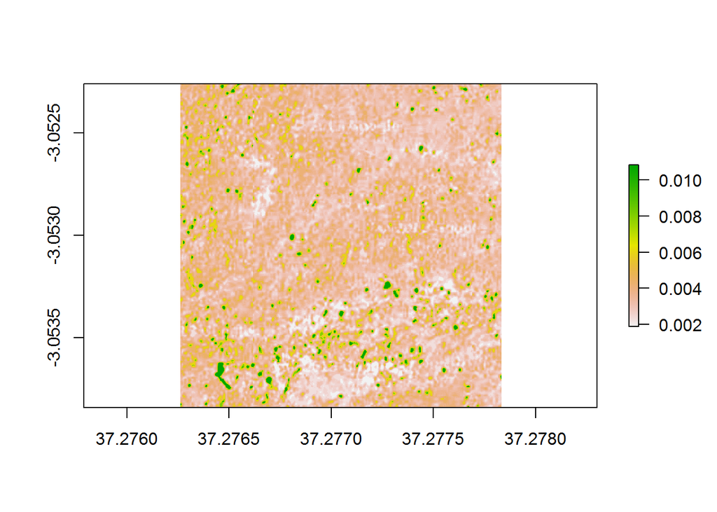

```r
plot(gmap_hel_vvi)
```

**Plot mask shadow**

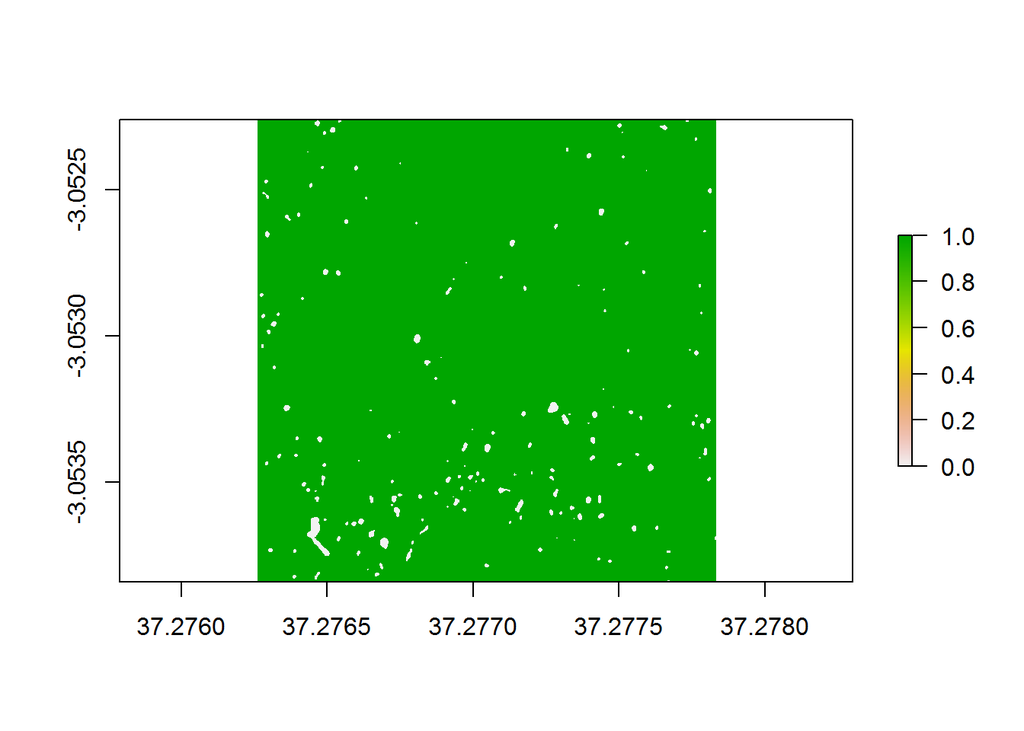

```r
plot(gmap_hel_shw)
```

## Image classification via kmeans()

The unsupervised image classification is realized via kmeans clustering. We focus on separating the 3 major land-cover types depicted above, namely:

- bare soil (class ‘A’),
- small to medium-sized vegetation (class ‘B’) and
- tall vegetation (class ‘C’).

Assemble relevant raster data:

```r
gmap_hel_all <- stack(gmap_hel, gmap_hel_fcmu, gmap_hel_fcsd, gmap_hel_vvi)
```

Convert to matrix

```r
mat_hel_all <- as.matrix(gmap_hel_all)
```

The land surface is dominated by small to medium-sized shrubs (medium brown) with smaller proportions of tall bushes (dark brown) and bare soil (light brown). Also included are shadows (dark brown to black), which are typically located next to tall vegetation.

**K-means clustering with 3 target groups**

```r
kmn_hel_all <- kmeans(mat_hel_all, centers = 3, iter.max = 100, nstart = 10)
```

After inserting the classification results into a separate raster template (rst_tmp), an additional class for shadow (tagged ‘0’) is created through multiplication with the initially created shadow mask.

```r
## raster template
rst_tmp <- gmap_hel[[1]]

## insert values
rst_tmp[] <- kmn_hel_all$cluster

## apply shadow mask
rst_tmp <- rst_tmp * gmap_hel_shw
```

## Visualization

Some lines to visualize the final raster. Each color is a class:

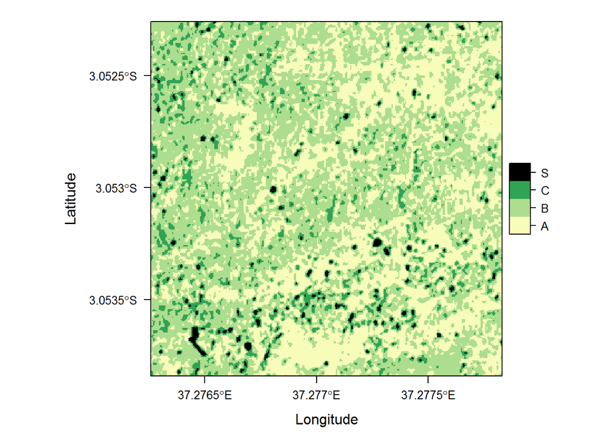

```r
rat_tmp <- ratify(rst_tmp)
rat <- rat_tmp@data@attributes[[1]]
rat$Class <- c("S", "C", "A", "B")
rat <- rat[order(rat$Class), , ]
levels(rat_tmp) <- rat

ylgn <- brewer.pal(3, "YlGn")
names(ylgn) <- c("A", "B", "C")
ylgnbl <- c(ylgn, c("S" = "black"))

levelplot(rat_tmp, col.regions = ylgnbl)
```